# Projet 10 : Détection de faux billets

L’Organisation nationale de lutte contre le faux-monnayage, ou ONCFM, est une organisation publique ayant pour objectif de mettre en place des méthodes d’identification des contrefaçons des billets en euros. Dans le cadre de cette lutte, nous souhaitons mettre en place un algorithme qui soit capable de différencier automatiquement les vrais des faux billets.

**Objectif :** Lorsqu’un billet arrive, nous avons une machine qui consigne l’ensemble de ses caractéristiques géométriques. Au travers de nos années de lutte, nous avons observé des différences de dimensions entre les vrais et les faux billets. Ces différences sont difficilement notables à l’œil nu, mais une machine devrait sans problème arriver à les différencier. Ainsi, il faudrait construire un algorithme qui, à partir des caractéristiques géométriques d’un billet, serait capable de définir si ce dernier est un vrai ou un faux billet.

```python
#Importation des librairies

#Générales
import pandas as pd
import numpy as np
import seaborn as sns
import matplotlib.pyplot as plt

#Pour la régression linéaire
import statsmodels.api as sm
from sklearn import linear_model
from sklearn.model_selection import train_test_split
from sklearn.linear_model import LinearRegression
from sklearn.metrics import mean_squared_error
from scipy.stats import t, shapiro
from statsmodels.stats.outliers_influence import variance_inflation_factor
import statsmodels
from statsmodels.formula.api import ols
from scipy.stats import bartlett
from scipy.stats import levene
from statsmodels.stats.diagnostic import het_white, normal_ad

#Pour la régression logistique
from sklearn import preprocessing
from sklearn.linear_model import LogisticRegression
import statsmodels.formula.api as smf
from sklearn.metrics import confusion_matrix
from sklearn.metrics import classification_report
from sklearn.metrics import roc_auc_score
from sklearn.metrics import roc_curve

#Pour le KNN
from sklearn.ensemble import RandomForestRegressor
from sklearn import utils
from sklearn.impute import KNNImputer
from sklearn.neighbors import KNeighborsClassifier
from sklearn.preprocessing import StandardScaler

#ACP
from functions import *
from sklearn import decomposition, preprocessing
from sklearn.decomposition import PCA
from sklearn.cluster import KMeans, AgglomerativeClustering
from sklearn.metrics import silhouette_score
from scipy.cluster.hierarchy import linkage, fcluster, dendrogram
```

# 1. Préparation et description des données

```python
#Importation de la table
billets = pd.read_csv('billets.csv', sep=';')

#Visualisation
display(billets.head(5))
display(billets.info())
display(billets.shape)
```

|  | is_genuine | diagonal | height_left | height_right | margin_low | margin_up | length |
| --- | --- | --- | --- | --- | --- | --- | --- |
| 0 | True | 171.81 | 104.86 | 104.95 | 4.52 | 2.89 | 112.83 |
| 1 | True | 171.46 | 103.36 | 103.66 | 3.77 | 2.99 | 113.09 |
| 2 | True | 172.69 | 104.48 | 103.50 | 4.40 | 2.94 | 113.16 |
| 3 | True | 171.36 | 103.91 | 103.94 | 3.62 | 3.01 | 113.51 |
| 4 | True | 171.73 | 104.28 | 103.46 | 4.04 | 3.48 | 112.54 |

```
<class 'pandas.core.frame.DataFrame'>
RangeIndex: 1500 entries, 0 to 1499
Data columns (total 7 columns):
 #   Column        Non-Null Count  Dtype
---  ------        --------------  -----
 0   is_genuine    1500 non-null   bool
 1   diagonal      1500 non-null   float64
 2   height_left   1500 non-null   float64
 3   height_right  1500 non-null   float64
 4   margin_low    1463 non-null   float64
 5   margin_up     1500 non-null   float64
 6   length        1500 non-null   float64
dtypes: bool(1), float64(6)
memory usage: 71.9 KB
```

```
None
```

```
(1500, 7)
```

```python
# Proportion de vrais et faux billets
billets['is_genuine'].value_counts()
```

```
True     1000
False     500
Name: is_genuine, dtype: int64
```

```python
# Résumé des valeurs manquantes
billets.isna().sum()
```

```
is_genuine       0
diagonal         0
height_left      0
height_right     0
margin_low      37
margin_up        0
length           0
dtype: int64
```

```python
## Standardisation des variables
billets_norm = preprocessing.scale(billets)
```

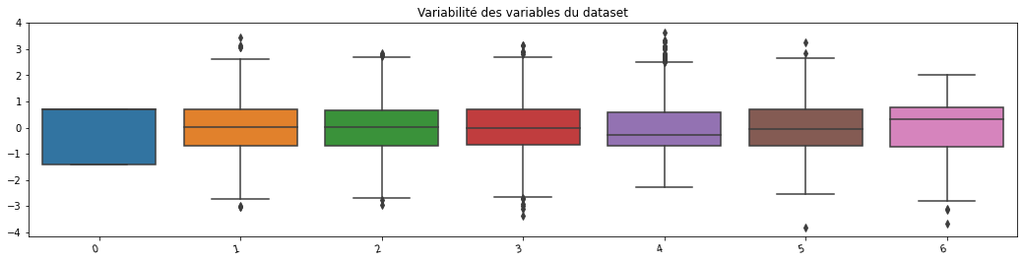

```python
# Visualition de la variablité des variables du dataset
plt.figure(figsize = (18,4))
chart = sns.boxplot(data = billets_norm)
chart.set_xticklabels(chart.get_xticklabels(), rotation=15, horizontalalignment='right')
plt.title('Variabilité des variables du dataset')
plt.show()
```

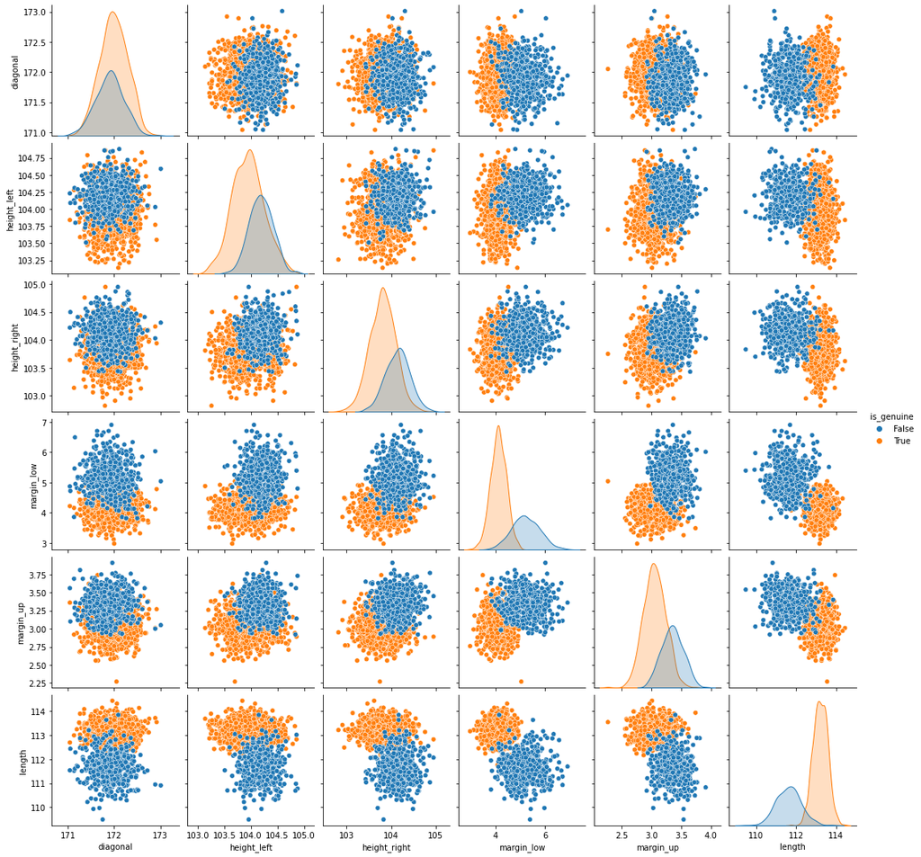

```python
# Pairplot pour voir quelles variables pourraient permettre de différencier les V/F
sns.pairplot(billets, hue='is_genuine')
plt.show()
```

```python
# Préparation des données
X = billets[billets.columns[1:7]].values
country = billets.index
header = billets.columns[1:7]
features = billets.columns
```

```python
# Centrage et Réduction
X_scaled = preprocessing.StandardScaler().fit_transform(X)
df_X_scaled = pd.DataFrame(X_scaled,columns=header)
df_X_scaled.describe().round(4)
```

|  | diagonal | height_left | height_right | margin_low | margin_up | length |
| --- | --- | --- | --- | --- | --- | --- |
| count | 1500.0000 | 1500.0000 | 1500.0000 | 1463.0000 | 1500.0000 | 1500.0000 |
| mean | -0.0000 | 0.0000 | -0.0000 | 0.0000 | -0.0000 | 0.0000 |
| std | 1.0003 | 1.0003 | 1.0003 | 1.0003 | 1.0003 | 1.0003 |
| min | -3.0104 | -2.9714 | -3.3802 | -2.2694 | -3.8038 | -3.6547 |
| 25% | -0.6832 | -0.6999 | -0.6461 | -0.7097 | -0.6968 | -0.7433 |
| 50% | 0.0051 | 0.0350 | -0.0009 | -0.2652 | -0.0495 | 0.3227 |
| 75% | 0.6934 | 0.6696 | 0.7056 | 0.5787 | 0.6841 | 0.7582 |
| max | 3.4467 | 2.8409 | 3.1632 | 3.6379 | 3.2732 | 2.0191 |

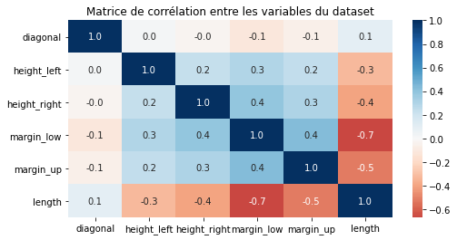

```python
# Matrice de corrélation de Pearson
plt.figure(figsize=(8,4))
sns.heatmap(df_X_scaled.corr(), cmap='RdBu', center=0, annot=True, fmt='.1f',)
plt.title ('Matrice de corrélation entre les variables du dataset')
#plt.savefig('matrice_P10.png', bbox_inches='tight')
plt.show()
```

# 2. Imputation des valeurs manquantes

```python
# On sépare les valeurs nulles pour créer un df "missing_margin_low"
missing_margin_low = billets[billets['margin_low'].isnull()]
missing_margin_low.info()
display(missing_margin_low.sample(10))
```

```
<class 'pandas.core.frame.DataFrame'>
Int64Index: 37 entries, 72 to 1438
Data columns (total 7 columns):
 #   Column        Non-Null Count  Dtype
---  ------        --------------  -----
 0   is_genuine    37 non-null     bool
 1   diagonal      37 non-null     float64
 2   height_left   37 non-null     float64
 3   height_right  37 non-null     float64
 4   margin_low    0 non-null      float64
 5   margin_up     37 non-null     float64
 6   length        37 non-null     float64
dtypes: bool(1), float64(6)
memory usage: 2.1 KB
```

|  | is_genuine | diagonal | height_left | height_right | margin_low | margin_up | length |
| --- | --- | --- | --- | --- | --- | --- | --- |
| 505 | True | 172.01 | 103.97 | 104.05 | NaN | 2.98 | 113.65 |
| 945 | True | 172.09 | 103.74 | 103.52 | NaN | 3.02 | 112.78 |
| 72 | True | 171.94 | 103.89 | 103.45 | NaN | 3.25 | 112.79 |
| 742 | True | 172.14 | 104.06 | 103.96 | NaN | 3.24 | 113.07 |
| 251 | True | 171.80 | 103.26 | 102.82 | NaN | 2.95 | 113.22 |
| 871 | True | 171.37 | 104.07 | 103.75 | NaN | 3.07 | 113.27 |
| 151 | True | 172.07 | 103.80 | 104.38 | NaN | 3.02 | 112.93 |
| 410 | True | 172.56 | 103.72 | 103.51 | NaN | 3.12 | 112.95 |
| 1315 | False | 172.08 | 104.15 | 104.17 | NaN | 3.40 | 112.29 |
| 241 | True | 171.83 | 104.14 | 104.06 | NaN | 3.02 | 112.36 |

## 2.1. Avec méthode "dummy" par la moyenne

```python
# Drop des valeurs nulles du df "billets" pour représenter "billets_full", ce qu'on utilisera pour faire les trains et tests sets
billets_full = billets.dropna()

X = billets_full.iloc[:, ~billets_full.columns.isin(['margin_low', 'is_genuine'])]
y = billets_full.iloc[:, billets_full.columns.isin(['margin_low'])]

X1_train, X1_test, y1_train, y1_test = train_test_split(X, y, test_size=0.25, random_state=42)
```

```python
# Dummy model
y1_pred = np.full(y1_test.shape, y1_train.mean()) # créée un array de la même taille que y_test
MSE = mean_squared_error(y1_test, y1_pred)
RMSE = np.sqrt(MSE)
print("RMSE :", RMSE)
```

```
RMSE : 0.6508803308086563
```

RMSE : Racine de l'erreur quadratique moyenne, une valeur proche de 0 indique un ajustement presque parfait. On décide ici de ne pas faire la moyenne par groupe car on veut éviter l'overfitting.

## 2.2. KNN Imputer

```python
rmse = lambda y, yhat: np.sqrt(mean_squared_error(y, yhat))
```

```python
# Création d'une fonction qui va tester chaque modèle KNN imputer en fonction du nombre de k choisis et retourner les valeurs de RMSE
def optimize_k(data, target):
    errors = []
    for k in range(1, 6, 1):
        imputer = KNNImputer(n_neighbors=k)
        imputed = imputer.fit_transform(billets)
        df_imputed = pd.DataFrame(imputed, columns=billets.columns)

        X = df_imputed.drop(target, axis=1)
        y = df_imputed[target]
        X_train, X_test, y_train, y_test = train_test_split(X, y, test_size=0.2, random_state=42)

        model = RandomForestRegressor()
        model.fit(X_train, y_train)
        preds = model.predict(X_test)
        error = rmse(y_test, preds)
        errors.append({'K': k, 'RMSE': error})

    return errors
```

```python
k_errors = optimize_k(data=billets, target='margin_low')
```

```python
k_errors
```

```
[{'K': 1, 'RMSE': 0.4282263265688679},
 {'K': 2, 'RMSE': 0.42907716654466727},
 {'K': 3, 'RMSE': 0.4300962474196265},
 {'K': 4, 'RMSE': 0.4258926198047659},
 {'K': 5, 'RMSE': 0.42599291135103806}]
```

## 2.3. Avec une régression linéaire simple

```python
# Drop des valeurs nulles du df "billets" pour représenter "train_data"
billets_full = billets.dropna()

#On prend la variable qui semble fortement corrélée à margin_low (ici length, négativement fortement corrélée)
Xslr = billets_full.iloc[:, billets_full.columns.isin(['length'])]
yslr = billets_full.iloc[:, billets_full.columns.isin(['margin_low'])]

X_train_slr, X_test_slr, y_train_slr, y_test_slr = train_test_split(Xslr, yslr, test_size=0.25, random_state=42)

# Modèle de régression linéaire simple
lr = LinearRegression()
simple_lr_model = lr.fit(X_train_slr, y_train_slr)

# On applique le modèle sur x_test de test_data pour faire les prédictions
y_pred_slr = lr.predict(X_test_slr)

# On verifie la perf du model
MSE_slr = mean_squared_error(y_test_slr, y_pred_slr)
RMSE_slr = np.sqrt(MSE_slr)
print(RMSE_slr)
```

```
0.4700922565944395
```

## 2.4. Avec une régression linéaire multiple

```python
# Régression linéiare multiple avec toutes les variables numériques

X = billets_full.iloc[:, ~billets_full.columns.isin(['margin_low', 'is_genuine'])]
X = sm.add_constant(X) # ajout constante
y = billets_full.iloc[:, billets_full.columns.isin(['margin_low'])]

X_train2, X_test2, y_train2, y_test2 = train_test_split(X, y, test_size=0.25, random_state=42)

reg_multi = sm.OLS(y_train2, X_train2).fit()
print(reg_multi.summary())

y_pred2 = reg_multi.predict(X_test2)

# On verifie la perf du model
MSE_reg = mean_squared_error(y_test2, y_pred2)
RMSE_reg = np.sqrt(MSE_reg)
print("RMSE :", RMSE_reg)
```

```
                            OLS Regression Results
==============================================================================
Dep. Variable:             margin_low   R-squared:                       0.470
Model:                            OLS   Adj. R-squared:                  0.467
Method:                 Least Squares   F-statistic:                     193.1
Date:                Fri, 25 Nov 2022   Prob (F-statistic):          2.00e-147
Time:                        07:34:25   Log-Likelihood:                -765.89
No. Observations:                1097   AIC:                             1544.
Df Residuals:                    1091   BIC:                             1574.
Df Model:                           5
Covariance Type:            nonrobust
================================================================================
                   coef    std err          t      P>|t|      [0.025      0.975]
--------------------------------------------------------------------------------
const           16.7325     11.455      1.461      0.144      -5.743      39.208
diagonal        -0.0931      0.049     -1.897      0.058      -0.189       0.003
height_left      0.1933      0.053      3.680      0.000       0.090       0.296
height_right     0.2723      0.050      5.461      0.000       0.174       0.370
margin_up        0.2663      0.076      3.510      0.000       0.117       0.415
length          -0.4037      0.021    -18.960      0.000      -0.445      -0.362
==============================================================================
Omnibus:                       68.446   Durbin-Watson:                   1.986
Prob(Omnibus):                  0.000   Jarque-Bera (JB):               88.562
Skew:                           0.560   Prob(JB):                     5.88e-20
Kurtosis:                       3.825   Cond. No.                     1.97e+05
==============================================================================

Notes:
[1] Standard Errors assume that the covariance matrix of the errors is correctly specified.
[2] The condition number is large, 1.97e+05. This might indicate that there are
strong multicollinearity or other numerical problems.
RMSE : 0.45958853193139215
```

Toutes nos variables n'ont une valeur p inférieure à 0,05, on les enlève pour le modèle final car non significatives.

```python
# Régression linéiare multiple avec les variables numériques sélectionnées

X = billets_full.iloc[:, ~billets_full.columns.isin(['margin_low', 'is_genuine', 'diagonal'])]
y = billets_full.iloc[:, billets_full.columns.isin(['margin_low'])]

X_train2, X_test2, y_train2, y_test2 = train_test_split(X, y, test_size=0.25, random_state=42)

reg_multi = sm.OLS(y_train2, X_train2).fit()
print(reg_multi.summary())

y_pred2 = reg_multi.predict(X_test2)

# On verifie la perf du model
MSE_reg = mean_squared_error(y_test2, y_pred2)
RMSE_reg = np.sqrt(MSE_reg)
print("RMSE :", RMSE_reg)
```

```
                                 OLS Regression Results
=======================================================================================
Dep. Variable:             margin_low   R-squared (uncentered):                   0.988
Model:                            OLS   Adj. R-squared (uncentered):              0.988
Method:                 Least Squares   F-statistic:                          2.337e+04
Date:                Fri, 25 Nov 2022   Prob (F-statistic):                        0.00
Time:                        07:34:25   Log-Likelihood:                         -767.72
No. Observations:                1097   AIC:                                      1543.
Df Residuals:                    1093   BIC:                                      1563.
Df Model:                           4
Covariance Type:            nonrobust
================================================================================
                   coef    std err          t      P>|t|      [0.025      0.975]
--------------------------------------------------------------------------------
height_left      0.1945      0.040      4.840      0.000       0.116       0.273
height_right     0.2788      0.039      7.205      0.000       0.203       0.355
margin_up        0.2688      0.076      3.542      0.000       0.120       0.418
length          -0.4044      0.017    -23.435      0.000      -0.438      -0.371
==============================================================================
Omnibus:                       69.899   Durbin-Watson:                   1.980
Prob(Omnibus):                  0.000   Jarque-Bera (JB):               91.121
Skew:                           0.566   Prob(JB):                     1.63e-20
Kurtosis:                       3.844   Cond. No.                         969.
==============================================================================

Notes:
[1] R² is computed without centering (uncentered) since the model does not contain a constant.
[2] Standard Errors assume that the covariance matrix of the errors is correctly specified.
RMSE : 0.46204736113362627
```

R2 : indique la proportion de points qui sont dans la ligne créée par la régression linéaire (plus c'est proche de 1, mieux c'est); ici avec la régression linéaire multiple, on est à 0,988 donc très bon.

## 2.2.1. Tests de validité du modèle de régression linéaire

F-Test (ANOVA) / Les tests F sont couramment utilisés pour étudier les cas suivants:

- L'hypothèse que les moyennes de différents ensembles de données dont la distribution suit une loi normale, ayant tous le même écart-type, sont égales. Il s'agit du test F le plus connu et il joue un rôle important dans l'analyse de la variance (ANOVA).
- L'hypothèse qu'un modèle de régression proposé convient bien aux données. Voir Manque d'ajustement d'une somme des carrés.
- L'hypothèse que, dans le cas d'une analyse de régression, un jeu de données suit le plus simple des deux modèles linéaires proposés lorsque ces modèles sont imbriqués l'un dans l'autre.
- Test de Fisher d'égalité de deux variances
- Test exact de Fisher

```python
print('F-statistic:', reg_multi.fvalue)
print('Probability of observing value at least as high as F-statistic:', reg_multi.f_pvalue)
```

```
F-statistic: 23368.230505473734
Probability of observing value at least as high as F-statistic: 0.0
```

Comme notre valeur f_p est inférieure à 0,05, nous pouvons conclure que notre modèle est plus performant que les autres modèles plus simples.

```python
# On crée les colonnes "margin_low_pred" et 'residual' pour analyse plus tard
billets_full['margin_low_pred'] = reg_multi.predict(X)
billets_full['residual'] = reg_multi.resid
billets_full.head()
```

|  | is_genuine | diagonal | height_left | height_right | margin_low | margin_up | length | margin_low_pred | residual |
| --- | --- | --- | --- | --- | --- | --- | --- | --- | --- |
| 0 | True | 171.81 | 104.86 | 104.95 | 4.52 | 2.89 | 112.83 | 4.800314 | -0.280314 |
| 1 | True | 171.46 | 103.36 | 103.66 | 3.77 | 2.99 | 113.09 | 4.070682 | -0.300682 |
| 2 | True | 172.69 | 104.48 | 103.50 | 4.40 | 2.94 | 113.16 | 4.202156 | 0.197844 |
| 3 | True | 171.36 | 103.91 | 103.94 | 3.62 | 3.01 | 113.51 | 4.091235 | -0.471235 |
| 4 | True | 171.73 | 104.28 | 103.46 | 4.04 | 3.48 | 112.54 | 4.547962 | -0.507962 |

a) Normalité des résidus : L’objectif est de s’assurer que les résidus suivent une loi normale afin de ne pas affirmer qu’il existe une différence de moyenne entre les groupes qui serait causée par le hasard.

On utilise le test de Shapiro-Wilk pour tester la normalité des résidus où :

- H0 : Les résidus suivent une loi normale si p-value > 5%
- H1 : Les résidus ne suivent pas une loi normale si p-value < 5%

```python
# Normalité des résidus :
shapiro(reg_multi.resid)
```

```
ShapiroResult(statistic=0.9814221858978271, pvalue=1.2490590506342159e-10)
```

- ~H0 : Les résidus suivent une loi normale si p-value > 5%~
- H1 : Les résidus ne suivent pas une loi normale si p-value < 5%

```
p-value du test Anderson-Darling inf. à 0.05 non-normal: 0.0
```

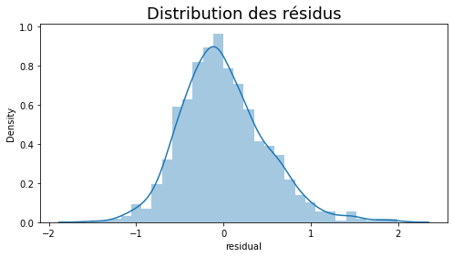

```
Les résidus ne sont pas distribués normalement
```

```python
from statsmodels.stats.diagnostic import normal_ad

# Test d'Anderson-Darling sur les résidus
p_value = normal_ad(billets_full['residual'])[1]
print('p-value du test Anderson-Darling inf. à 0.05 non-normal:', p_value)

# Plot de la distribution des résidus
plt.subplots(figsize=(8, 4))
plt.title('Distribution des résidus', fontsize=18)
sns.distplot(billets_full['residual'])
plt.show()

# Normalité des résidus
if p_value < 0.05:
    print('Les résidus ne sont pas distribués normalement')
else:
    print('Les résidus sont distribués normalement')
```

Néanmoins, le fait que l'échantillon soit de taille suffisante (supérieure à 30) permet de dire que **les résultats obtenus par le modèle linéaire gaussien ne sont pas absurdes**, même si le résidu n'est pas considéré comme étant gaussien.

b) Multicolinéarité

Linéarité

- Cela suppose qu'il existe une relation linéaire entre les variables indépendantes et la variable dépendante. Dans notre cas, puisque nous avons plusieurs variables indépendantes, nous pouvons le faire en utilisant un scatterplot pour voir nos valeurs prédites par rapport aux valeurs réelles.

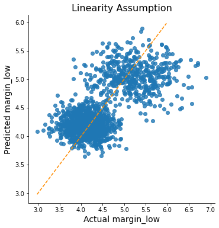

```python
# Plot des valeurs margin_low observées / prédites
sns.lmplot(x='margin_low', y='margin_low_pred', data=billets_full, fit_reg=False, size=5)

# Ligne diagonale
line_coords = np.arange(billets_full[['margin_low', 'margin_low_pred']].min().min(),
                        billets_full[['margin_low', 'margin_low_pred']].max().max())
plt.plot(line_coords, line_coords,  # X and y points
         color='darkorange', linestyle='--')

plt.ylabel('Predicted margin_low', fontsize=14)
plt.xlabel('Actual margin_low', fontsize=14)
plt.title('Linearity Assumption', fontsize=16)
plt.show()
```

La multicolinéarité se produit lorsqu’il existe deux ou plusieurs variables indépendantes dans un modèle de régression multiple, qui ont une forte corrélation entre elles. Lorsque certaines caractéristiques sont fortement corrélées, nous pouvons avoir des difficultés à distinguer leurs effets individuels sur la variable dépendante. La multicolinéarité peut être détectée à l’aide de diverses techniques, l’une de ces techniques étant le facteur d’inflation de la variance (VIF).

```python
# Les variables du dataset
X = billets_full[['diagonal', 'height_left', 'height_right', 'margin_low', 'margin_up', 'length']]

# VIF dataframe
vif_data = pd.DataFrame()
vif_data["feature"] = X.columns

# Calcul du VIF pour chacun
vif_data["VIF"] = [variance_inflation_factor(X.values, i)
                          for i in range(len(X.columns))]

print(vif_data)
print("VIF moyen:",vif_data.mean())
```

```
        feature            VIF
0      diagonal  170808.246898
1   height_left  114373.426488
2  height_right  105157.499668
3    margin_low      89.003990
4     margin_up     264.908266
5        length   31205.638468
VIF moyen: VIF    70316.453963
dtype: float64
```

Comme nous pouvons le voir, plusieurs variables ont des valeurs très élevées de VIF, indiquant que ces variables sont fortement corrélées. Par conséquent, considérer ces caractéristiques ensemble conduit à un modèle à forte multicolinéarité.

c) Homoscédasticité

On peut également tester l’homoscédasticité (c'est-à-dire la constance de la variance) des résidus :

```python
billets_full.groupby('is_genuine').agg('var')
```

| is_genuine | diagonal | height_left | height_right | margin_low | margin_up | length | margin_low_pred | residual |
| --- | --- | --- | --- | --- | --- | --- | --- | --- |
| False | 0.093314 | 0.050364 | 0.073812 | 0.306397 | 0.032164 | 0.378647 | 0.072863 | 0.399891 |
| True | 0.090843 | 0.090913 | 0.083441 | 0.101840 | 0.034382 | 0.126823 | 0.032812 | 0.136262 |

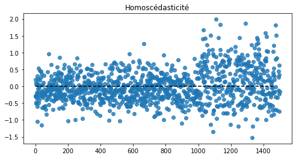

```python
# Graphique:
plt.subplots(figsize=(8, 4))
plt.scatter(x=billets_full.index, y=billets_full.residual, alpha=0.8)
plt.plot(np.repeat(0, len(billets_full.index)+2), color="black", linestyle='--')
plt.title("Homoscédasticité")
```

La répartition semble aléatoire sur le graphique, même si ça tend à avoir une répartition de plus en plus dispersée.

```python
# Test de Breusch Pagan pour l'homoscédasticité :
variables = reg_multi.model.exog
_, pval, __, f_pval = statsmodels.stats.diagnostic.het_breuschpagan(reg_multi.resid, variables)
print('p value test Breusch Pagan:', pval)
```

```
p value test Breusch Pagan: 4.9180695959531245e-71
```

La p-valeur ici est inférieure à $5$%, on rejette l'hypothèse $H0$ (l'hypothèse d’homoscédasticité) selon laquelle les variances sont constantes comme vu lors du calcul du VIF.

Même si toutes les hypothèses ne sont pas vérifiées, le modèle linéaire semble robuste, c'est-à-dire que sous réserve qu'il y ait une taille d'échantillon suffisante, les résultats du modèle linéaire restent valables. On parle de propriétés asymptotiques (i.e. des propriétés valables si n, la taille d'échantillon "tend vers l'infini"...). (http://perso.ens-lyon.fr/lise.vaudor/non-respect-des-hypotheses-du-modele-lineaire-anova-regression-cest-grave-docteur/)

## 2.2.2. Application du modèle

```python
# On replace les valeurs manquantes par les valeurs prédites

X_train = billets_full.drop(columns=['diagonal', 'is_genuine', 'margin_low', 'margin_low_pred', 'residual'])
y_train = billets_full['margin_low']
X_test = missing_margin_low.drop(columns=['diagonal', 'is_genuine', 'margin_low'])


model = sm.OLS(y_train, X_train).fit()
missing_margin_low['margin_low'] = model.predict(X_test)
```

```python
billets_full = billets_full.drop(columns=['margin_low_pred', 'residual'])
```

```python
new_data = pd.concat([billets_full, missing_margin_low])
display(new_data.info())
display(new_data.shape)
```

```
<class 'pandas.core.frame.DataFrame'>
Int64Index: 1500 entries, 0 to 1438
Data columns (total 7 columns):
 #   Column        Non-Null Count  Dtype
---  ------        --------------  -----
 0   is_genuine    1500 non-null   bool
 1   diagonal      1500 non-null   float64
 2   height_left   1500 non-null   float64
 3   height_right  1500 non-null   float64
 4   margin_low    1500 non-null   float64
 5   margin_up     1500 non-null   float64
 6   length        1500 non-null   float64
dtypes: bool(1), float64(6)
memory usage: 83.5 KB
```

```
None
```

```
(1500, 7)
```

```python
## Standardisation des variables
new_data_norm = preprocessing.scale(new_data)
```

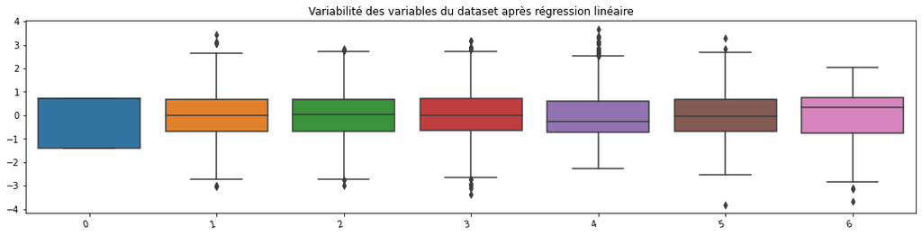

```python
# Visualition de la variablité des variables du dataset après la régression linéaire multiple
plt.figure(figsize = (18,4))
chart = sns.boxplot(data = new_data_norm)
chart.set_xticklabels(chart.get_xticklabels(), rotation=15, horizontalalignment='right')
plt.title('Variabilité des variables du dataset après régression linéaire')
plt.show()
```

# 4. Prédiction des vrais et faux billets d'après leurs dimensions

## 4.1. Avec une régression logistique

```python
# Entrainement

X_billet = new_data.loc[:, new_data.columns != 'is_genuine']
y_billet = new_data.loc[:, new_data.columns == 'is_genuine']

X_train_log, X_test_log, y_train_log, y_test_log = train_test_split(X_billet, y_billet, test_size=0.25, random_state=42)

logit_model = sm.Logit(y_train_log,X_train_log)
result = logit_model.fit()
print(result.summary2())
```

```
Optimization terminated successfully.
         Current function value: 0.028956
         Iterations 11
                          Results: Logit
==================================================================
Model:              Logit            Pseudo R-squared: 0.954
Dependent Variable: is_genuine       AIC:              77.1514
Date:               2022-11-25 07:34 BIC:              107.3047
No. Observations:   1125             Log-Likelihood:   -32.576
Df Model:           5                LL-Null:          -707.47
Df Residuals:       1119             LLR p-value:      1.0419e-289
Converged:          1.0000           Scale:            1.0000
No. Iterations:     11.0000
------------------------------------------------------------------
                  Coef.   Std.Err.    z    P>|z|   [0.025   0.975]
------------------------------------------------------------------
diagonal          -0.4748   0.7818 -0.6073 0.5436  -2.0072  1.0576
height_left       -1.0364   1.2183 -0.8507 0.3950  -3.4242  1.3514
height_right      -3.6399   1.2470 -2.9190 0.0035  -6.0839 -1.1959
margin_low        -6.0958   1.1153 -5.4658 0.0000  -8.2817 -3.9099
margin_up        -10.9062   2.4428 -4.4645 0.0000 -15.6941 -6.1183
length             5.6058   0.9582  5.8503 0.0000   3.7277  7.4838
==================================================================
```

Certaines variables doivent être supprimées (p-value non significatives).

```python
# Entrainement sans diagonal et height left

X_billet = new_data.drop(columns=['is_genuine', 'diagonal', 'height_left'])
y_billet = new_data.loc[:, new_data.columns == 'is_genuine']

X_train_log, X_test_log, y_train_log, y_test_log = train_test_split(X_billet, y_billet, test_size=0.25, random_state=42)

logit_model = sm.Logit(y_train_log, X_train_log)
result = logit_model.fit()
print(result.summary2())
```

```
Optimization terminated successfully.
         Current function value: 0.029734
         Iterations 11
                          Results: Logit
==================================================================
Model:              Logit            Pseudo R-squared: 0.953
Dependent Variable: is_genuine       AIC:              74.9009
Date:               2022-11-25 07:34 BIC:              95.0031
No. Observations:   1125             Log-Likelihood:   -33.450
Df Model:           3                LL-Null:          -707.47
Df Residuals:       1121             LLR p-value:      5.5421e-292
Converged:          1.0000           Scale:            1.0000
No. Iterations:     11.0000
------------------------------------------------------------------
                  Coef.   Std.Err.    z    P>|z|   [0.025   0.975]
------------------------------------------------------------------
height_right      -5.0511   0.8248 -6.1242 0.0000  -6.6677 -3.4346
margin_low        -6.0761   1.0387 -5.8495 0.0000  -8.1120 -4.0402
margin_up        -11.0121   2.3430 -4.7001 0.0000 -15.6043 -6.4200
length             5.2295   0.8019  6.5211 0.0000   3.6577  6.8012
==================================================================
```

Pseudo R2 proche de 1, régression logistique à priori fiable.

```python
# Test de la régression logistique
logreg = LogisticRegression()
logreg.fit(X_train_log, y_train_log)
```

```
LogisticRegression()
```

```python
y_pred_log = logreg.predict(X_test_log)
print('Accuracy of logistic regression classifier on test set: {:.2f}'.format(logreg.score(X_test_log, y_test_log)))
```

```
Accuracy of logistic regression classifier on test set: 0.99
```

```python
# Matrice de confusion
conf_mat = pd.DataFrame(confusion_matrix(y_test_log, y_pred_log),
                        columns=["Pred.Negative", "Pred.Positive"],
                        index=['Act.Negative', "Act.Positive"])
tn, fp, fn, tp = confusion_matrix(y_test_log, y_pred_log).ravel()
accuracy = round((tn+tp)/(tn+fp+fn+tp), 4)
print(conf_mat)
print(f'\n Accuracy = {round(100*accuracy, 2)}%')
```

```
              Pred.Negative  Pred.Positive
Act.Negative            135              2
Act.Positive              2            236

 Accuracy = 98.93%
```

==> Le modèle de régression logistique a atteint une précision de 98.93% dans ses prédictions.

Remarque : Bonne proportion de vrais et faux utilisés pour la prédiction.

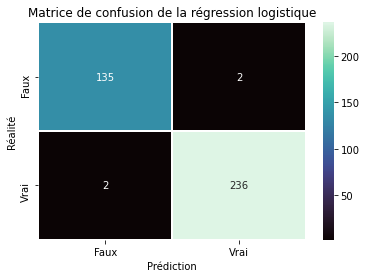

```python
#Graphique

sns.heatmap(conf_mat,
            annot = True,
           fmt = ".3g",
           cmap = sns.color_palette("mako", as_cmap=True),
           linecolor = "white",
           linewidths = 0.3,
           xticklabels = ["Faux", "Vrai"],
           yticklabels = ["Faux", "Vrai"]
           )
plt.xlabel("Prédiction")
plt.ylabel("Réalité")
plt.title("Matrice de confusion de la régression logistique")
```

```python
print(classification_report(y_test_log, y_pred_log))
```

```
              precision    recall  f1-score   support

       False       0.99      0.99      0.99       137
        True       0.99      0.99      0.99       238

    accuracy                           0.99       375
   macro avg       0.99      0.99      0.99       375
weighted avg       0.99      0.99      0.99       375
```

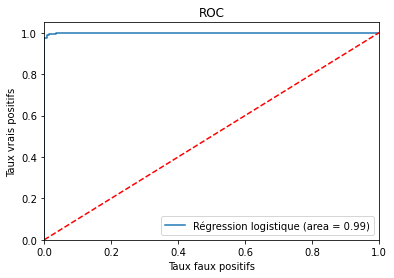

```python
logit_roc_auc = roc_auc_score(y_test_log, logreg.predict(X_test_log))
fpr, tpr, thresholds = roc_curve(y_test_log, logreg.predict_proba(X_test_log)[:,1])
plt.figure()
plt.plot(fpr, tpr, label='Régression logistique (area = %0.2f)' % logit_roc_auc)
plt.plot([0, 1], [0, 1],'r--')
plt.xlim([0.0, 1.0])
plt.ylim([0.0, 1.05])
plt.xlabel('Taux faux positifs')
plt.ylabel('Taux vrais positifs')
plt.title('ROC')
plt.legend(loc="lower right")
plt.savefig('Log_ROC')
plt.show()
```

La courbe ROC (receiver operating characteristic) est un autre outil couramment utilisé avec les classifieurs binaires. La ligne en pointillé représente la courbe ROC d'un classificateur purement aléatoire; un bon classificateur reste aussi loin que possible de cette ligne (vers le coin supérieur gauche).

## 4.1.1. **Maintenant on simule sur les billets production**

```python
billets_prod = pd.read_csv('billets_production.csv', sep=',')
billets_prod = billets_prod.drop(columns = "id", axis = 1)
billets_prod.head()
```

|  | diagonal | height_left | height_right | margin_low | margin_up | length |
| --- | --- | --- | --- | --- | --- | --- |
| 0 | 171.76 | 104.01 | 103.54 | 5.21 | 3.30 | 111.42 |
| 1 | 171.87 | 104.17 | 104.13 | 6.00 | 3.31 | 112.09 |
| 2 | 172.00 | 104.58 | 104.29 | 4.99 | 3.39 | 111.57 |
| 3 | 172.49 | 104.55 | 104.34 | 4.44 | 3.03 | 113.20 |
| 4 | 171.65 | 103.63 | 103.56 | 3.77 | 3.16 | 113.33 |

```python
# Ajout d'une colonne "is_genuine_reg"
billets_prod["is_genuine_log"] = np.nan
billets_prod.head()
```

|  | diagonal | height_left | height_right | margin_low | margin_up | length | is_genuine_log |
| --- | --- | --- | --- | --- | --- | --- | --- |
| 0 | 171.76 | 104.01 | 103.54 | 5.21 | 3.30 | 111.42 | NaN |
| 1 | 171.87 | 104.17 | 104.13 | 6.00 | 3.31 | 112.09 | NaN |
| 2 | 172.00 | 104.58 | 104.29 | 4.99 | 3.39 | 111.57 | NaN |
| 3 | 172.49 | 104.55 | 104.34 | 4.44 | 3.03 | 113.20 | NaN |
| 4 | 171.65 | 103.63 | 103.56 | 3.77 | 3.16 | 113.33 | NaN |

```python
X_test = billets_prod.drop(columns=['is_genuine_log', 'diagonal', 'height_left'])

# On applique le modèle pour faire les prédictions
billets_prod['is_genuine_log'] = logreg.predict(X_test)
```

```python
billets_prod.head(5)
```

|  | diagonal | height_left | height_right | margin_low | margin_up | length | is_genuine_log |
| --- | --- | --- | --- | --- | --- | --- | --- |
| 0 | 171.76 | 104.01 | 103.54 | 5.21 | 3.30 | 111.42 | False |
| 1 | 171.87 | 104.17 | 104.13 | 6.00 | 3.31 | 112.09 | False |
| 2 | 172.00 | 104.58 | 104.29 | 4.99 | 3.39 | 111.57 | False |
| 3 | 172.49 | 104.55 | 104.34 | 4.44 | 3.03 | 113.20 | True |
| 4 | 171.65 | 103.63 | 103.56 | 3.77 | 3.16 | 113.33 | True |

# 4.2. Test avec un KNN Classifier

```python
new_data['is_genuine'] =  new_data['is_genuine'].astype('category')
```

```python
new_data.info()
```

```
<class 'pandas.core.frame.DataFrame'>
Int64Index: 1500 entries, 0 to 1438
Data columns (total 7 columns):
 #   Column        Non-Null Count  Dtype
---  ------        --------------  -----
 0   is_genuine    1500 non-null   category
 1   diagonal      1500 non-null   float64
 2   height_left   1500 non-null   float64
 3   height_right  1500 non-null   float64
 4   margin_low    1500 non-null   float64
 5   margin_up     1500 non-null   float64
 6   length        1500 non-null   float64
dtypes: category(1), float64(6)
memory usage: 83.6 KB
```

```python
# Ajout d'une colonne "is_genuine_knn"
billets_prod["is_genuine_knn"] = np.nan
billets_prod.head()
```

|  | diagonal | height_left | height_right | margin_low | margin_up | length | is_genuine_log | is_genuine_knn |
| --- | --- | --- | --- | --- | --- | --- | --- | --- |
| 0 | 171.76 | 104.01 | 103.54 | 5.21 | 3.30 | 111.42 | False | NaN |
| 1 | 171.87 | 104.17 | 104.13 | 6.00 | 3.31 | 112.09 | False | NaN |
| 2 | 172.00 | 104.58 | 104.29 | 4.99 | 3.39 | 111.57 | False | NaN |
| 3 | 172.49 | 104.55 | 104.34 | 4.44 | 3.03 | 113.20 | True | NaN |
| 4 | 171.65 | 103.63 | 103.56 | 3.77 | 3.16 | 113.33 | True | NaN |

```python
# On replace les valeurs manquantes par les valeurs prédites

X_train = new_data.drop(columns=['is_genuine'])
y_train = new_data['is_genuine']
print(y_train)
y_train = y_train.astype('int')
print(y_train)
X_test = billets_prod.drop(columns=['is_genuine_knn', 'is_genuine_log'])

knn = KNeighborsClassifier(n_neighbors=2)

knn.fit(X_train, y_train)

billets_prod['is_genuine_knn'] = knn.predict(X_test)
```

```
0        True
1        True
2        True
3        True
4        True
        ...
1303    False
1315    False
1347    False
1435    False
1438    False
Name: is_genuine, Length: 1500, dtype: category
Categories (2, object): [False, True]
0       1
1       1
2       1
3       1
4       1
       ..
1303    0
1315    0
1347    0
1435    0
1438    0
Name: is_genuine, Length: 1500, dtype: int32
```

Remarque :

- 1 = True
- 0 = False

```python
billets_prod.head()
```

|  | diagonal | height_left | height_right | margin_low | margin_up | length | is_genuine_log | is_genuine_knn |
| --- | --- | --- | --- | --- | --- | --- | --- | --- |
| 0 | 171.76 | 104.01 | 103.54 | 5.21 | 3.30 | 111.42 | False | 0 |
| 1 | 171.87 | 104.17 | 104.13 | 6.00 | 3.31 | 112.09 | False | 0 |
| 2 | 172.00 | 104.58 | 104.29 | 4.99 | 3.39 | 111.57 | False | 0 |
| 3 | 172.49 | 104.55 | 104.34 | 4.44 | 3.03 | 113.20 | True | 1 |
| 4 | 171.65 | 103.63 | 103.56 | 3.77 | 3.16 | 113.33 | True | 1 |

Nous obtenons les mêmes résultats qu'avec la régression logistique.

# 4.3. K-Means

Interprétation graphique des composantes et de leur pourcentage de variance associée : avec le critère du Coude, cela permet de définir le nombre de composantes nécessaires pour atteindre un ratio de variance le plus élevé tout en conservant un nombre réduit de composantes.

```python
new_data.head()
```

|  | is_genuine | diagonal | height_left | height_right | margin_low | margin_up | length |
| --- | --- | --- | --- | --- | --- | --- | --- |
| 0 | True | 171.81 | 104.86 | 104.95 | 4.52 | 2.89 | 112.83 |
| 1 | True | 171.46 | 103.36 | 103.66 | 3.77 | 2.99 | 113.09 |
| 2 | True | 172.69 | 104.48 | 103.50 | 4.40 | 2.94 | 113.16 |
| 3 | True | 171.36 | 103.91 | 103.94 | 3.62 | 3.01 | 113.51 |
| 4 | True | 171.73 | 104.28 | 103.46 | 4.04 | 3.48 | 112.54 |

```python
# Préparation des données
X = new_data[new_data.columns[1:7]].values
header = new_data.columns[1:7]
features = new_data.columns
```

```python
# Centrage et Réduction
X_scaled = preprocessing.StandardScaler().fit_transform(X)
df_X_scaled = pd.DataFrame(X_scaled,columns=header)
df_X_scaled.describe().round(4)
```

|  | diagonal | height_left | height_right | margin_low | margin_up | length |
| --- | --- | --- | --- | --- | --- | --- |
| count | 1500.0000 | 1500.0000 | 1500.0000 | 1500.0000 | 1500.0000 | 1500.0000 |
| mean | 0.0000 | 0.0000 | -0.0000 | 0.0000 | -0.0000 | 0.0000 |
| std | 1.0003 | 1.0003 | 1.0003 | 1.0003 | 1.0003 | 1.0003 |
| min | -3.0104 | -2.9714 | -3.3802 | -2.2796 | -3.8038 | -3.6547 |
| 25% | -0.6832 | -0.6999 | -0.6461 | -0.7026 | -0.6968 | -0.7433 |
| 50% | 0.0051 | 0.0350 | -0.0009 | -0.2629 | -0.0495 | 0.3227 |
| 75% | 0.6934 | 0.6696 | 0.7056 | 0.5863 | 0.6841 | 0.7582 |
| max | 3.4467 | 2.8409 | 3.1632 | 3.6645 | 3.2732 | 2.0191 |

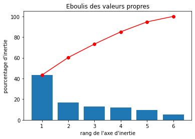

```python
# Sélection de 6 composantes correspondant aux 6 variables du dataset
num_components  = 6

# Création du modèle PCA
pca = decomposition.PCA(n_components=num_components)

# Entrainement du modèle sur les données standardisées
model = pca.fit(X_scaled)

# Eboulis des valeurs propres
display_scree_plot(pca)
```

```python
# Elbow Method
WCSS = [] # within-cluster sums of squares
for k in range (1,10):
    km = KMeans(n_clusters = k, init = "k-means++", random_state = 10)
    km.fit(X_scaled)
    WCSS.append(km.inertia_)

# Coefficient de Silhouette
silhouette_coefficients = []
for k in range(2, 10):
    kmeans = KMeans(n_clusters=k, n_init=10, init='k-means++')
    kmeans.fit(X_scaled)
    score = silhouette_score(X_scaled, kmeans.labels_)
    silhouette_coefficients.append(score)
```

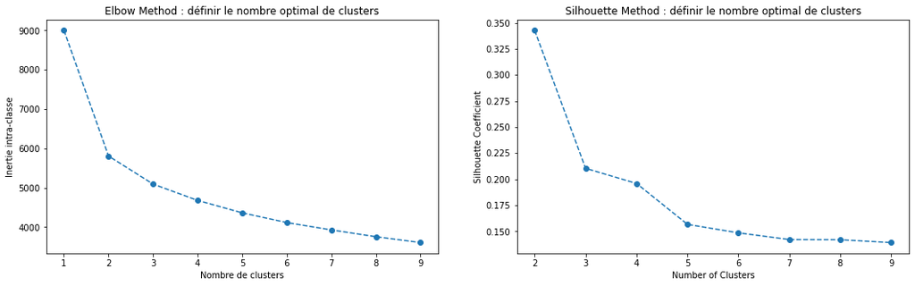

```python
fig = plt.figure(figsize=(18, 5))

# affichage des distorsions et sélection du nombre optimal de cluster avec la Elbow Method
ax1 = fig.add_subplot(121)
ax1.plot(range(1,10), WCSS, marker='o', linestyle='--')
ax1.set_xticks(range(1, 10))
ax1.set_xlabel('Nombre de clusters')
ax1.set_ylabel('Inertie intra-classe')
ax1.set_title('Elbow Method : définir le nombre optimal de clusters')

# affichage Silouhette Method
ax2 = fig.add_subplot(122)
ax2.plot(range(2, 10), silhouette_coefficients, marker='o', linestyle='--')
ax2.set_xticks(range(2, 10))
ax2.set_xlabel("Number of Clusters")
ax2.set_ylabel("Silhouette Coefficient")
ax2.set_title('Silhouette Method : définir le nombre optimal de clusters')

plt.show()
```

```python
# Projection des individus sur les axes principaux
X_projected = pca.transform(X_scaled)
```

```python
variabilite  = pd.DataFrame(X_projected, columns=['PC%s' % _ for _ in range(1,7)])
variabilite
```

|  | PC1 | PC2 | PC3 | PC4 | PC5 | PC6 |
| --- | --- | --- | --- | --- | --- | --- |
| 0 | 1.644203 | 0.744598 | 2.404533 | 3.180283 | 0.301648 | -0.011570 |
| 1 | -2.020553 | -2.206833 | -1.002963 | 0.072770 | 0.030072 | -0.473071 |
| 2 | -0.968757 | 2.621990 | 1.195831 | -0.924193 | -0.833657 | 0.204717 |
| 3 | -1.378086 | -1.819899 | 0.650823 | 0.827903 | 0.795692 | -0.228483 |
| 4 | 0.148646 | -0.568786 | 0.853411 | -1.787271 | 1.177957 | -0.302270 |
| ... | ... | ... | ... | ... | ... | ... |
| 1495 | 1.174429 | 0.931790 | 1.152432 | -0.526245 | -1.740220 | -0.862364 |
| 1496 | 1.349822 | 0.519336 | -0.291660 | 0.007611 | 0.533267 | 0.156312 |
| 1497 | 4.022960 | -0.504684 | 0.255739 | -0.982116 | -0.092261 | -0.537654 |
| 1498 | 2.843895 | 2.472064 | -0.831727 | -0.112937 | 0.345125 | 0.039427 |
| 1499 | 2.131316 | 0.058857 | 0.195239 | 0.463577 | -0.335605 | -0.329607 |

1500 rows × 6 columns

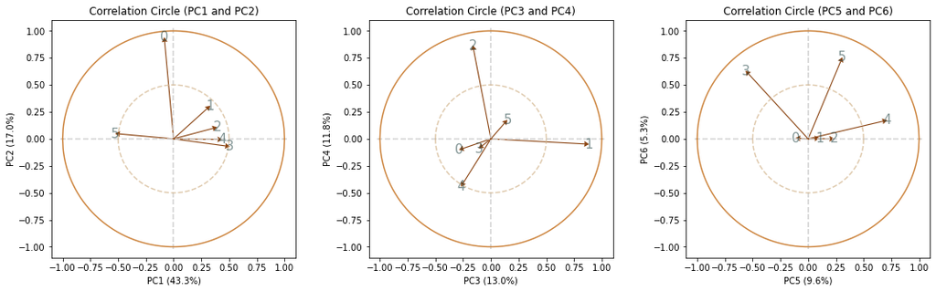

```python
# Génération des cercles de corrélations
pcs = pca.components_

df_num = pd.DataFrame(data=X_scaled)
nb = df_num.columns #numéro de variable

def display_circles(pcs, n_comp, pca, axis_ranks, labels=None, label_rotation=0, lims=None):
    """Display correlation circles, one for each factorial plane"""

    # Initialise the matplotlib figure
    fig, ax = plt.subplots(1,3, figsize=(18,5))
    plt.subplots_adjust(wspace=0.3)

    # For each factorial plane
    for k, (d1, d2) in enumerate(axis_ranks):
        if d2 < n_comp:

            # Determine the limits of the chart
            if lims is not None :
                xmin, xmax, ymin, ymax = lims
            elif pcs.shape[1] < 30 :
                xmin, xmax, ymin, ymax = -1, 1, -1, 1
            else :
                xmin, xmax, ymin, ymax = min(pcs[d1,:]), max(pcs[d1,:]), min(pcs[d2,:]), max(pcs[d2,:])

            # Add arrows
            # If there are more than 30 arrows, we do not display the triangle at the end
            if pcs.shape[1] < 30 :
                ax[k].quiver(np.zeros(pcs.shape[1]), np.zeros(pcs.shape[1]),
                             pcs[d1,:], pcs[d2,:], angles='xy', scale_units='xy',
                             scale=1, color="saddlebrown", headwidth=6, width=0.004,)
            else:
                lines = [[[0,0],[x,y]] for x,y in pcs[[d1,d2]].T]
                ax.add_collection(LineCollection(lines, axes=ax, alpha=.1, color='black'))

            # Display variable names
            if labels is not None:
                for i,(x, y) in enumerate(pcs[[d1,d2]].T):
                    if x >= xmin and x <= xmax and y >= ymin and y <= ymax :
                        ax[k].text(x, y, labels[i], fontsize='15', ha='center', va='center',
                                 rotation=label_rotation, color="darkslategrey", alpha=0.6)

            #Plot circle
            x=np.linspace(start=-1,stop=1,num=500)
            y_positive=lambda x: np.sqrt(1-x**2)
            y_negative=lambda x: -np.sqrt(1-x**2)
            ax[k].plot(x,list(map(y_positive, x)), color='peru')
            ax[k].plot(x,list(map(y_negative, x)),color='peru')

            #Plot smaller circle
            x=np.linspace(start=-0.5,stop=0.5,num=500)
            y_positive=lambda x: np.sqrt(0.5**2-x**2)
            y_negative=lambda x: -np.sqrt(0.5**2-x**2)
            ax[k].plot(x,list(map(y_positive, x)), color='tan', alpha=0.7, ls='--')
            ax[k].plot(x,list(map(y_negative, x)),color='tan', alpha=0.7, ls='--')

            #Create broken lines
            x=np.linspace(start=-1,stop=1,num=30)
            ax[k].scatter(x,[0]*len(x), marker='_',color='lightgrey')
            ax[k].scatter([0]*len(x), x, marker='|',color='lightgrey')

            # Label the axes, with the percentage of variance explained
            ax[k].set_xlabel('PC{} ({}%)'.format(d1+1, round(100*pca.explained_variance_ratio_[d1],1)))
            ax[k].set_ylabel('PC{} ({}%)'.format(d2+1, round(100*pca.explained_variance_ratio_[d2],1)))

            ax[k].set_title("Correlation Circle (PC{} and PC{})".format(d1+1, d2+1))


# sur les 3 premiers plans factoriels
display_circles(pcs, num_components, pca, [(0,1), (2,3), (4,5)], labels = nb)
```

```python
# Création d'une table des correspondances pour relier les numéros à leurs variables
print(pd.DataFrame(data={'Numéro' : nb, 'Intitulé' : header}))
```

```
   Numéro      Intitulé
0       0      diagonal
1       1   height_left
2       2  height_right
3       3    margin_low
4       4     margin_up
5       5        length
```

```python
# Dataframe pour les liaisons entre les variables : coefficient de chaque variable pour former une composante principale
liaisons = pd.DataFrame(pca.components_.T, columns=['PC%s' % _ for _ in range(1,7)], index=header).copy()
liaisons
```

|  | PC1 | PC2 | PC3 | PC4 | PC5 | PC6 |
| --- | --- | --- | --- | --- | --- | --- |
| diagonal | -0.084325 | 0.941692 | -0.287466 | -0.101646 | -0.114389 | 0.007265 |
| height_left | 0.330707 | 0.306830 | 0.885233 | -0.049464 | 0.101831 | 0.005940 |
| height_right | 0.393547 | 0.107656 | -0.163002 | 0.866877 | 0.235552 | 0.001182 |
| margin_low | 0.507716 | -0.071027 | -0.109432 | -0.089850 | -0.564032 | 0.631664 |
| margin_up | 0.439435 | -0.005739 | -0.270064 | -0.443391 | 0.712454 | 0.172464 |
| length | -0.527034 | 0.049042 | 0.149152 | 0.176289 | 0.308768 | 0.755756 |

```python
# Liaison des composantes principales avec les valeurs absolues des 3 variables les mieux représentées
for PC in liaisons.columns:
    df_representation = liaisons[PC].sort_values(ascending=False, key=abs).head(3)

    print('Variables qui contribuent le plus à', PC, '(valeurs absolues): \n',df_representation, "\n", '-'*50, '\n')
```

```
Variables qui contribuent le plus à PC1 (valeurs absolues):
 length       -0.527034
margin_low    0.507716
margin_up     0.439435
Name: PC1, dtype: float64
 --------------------------------------------------

Variables qui contribuent le plus à PC2 (valeurs absolues):
 diagonal        0.941692
height_left     0.306830
height_right    0.107656
Name: PC2, dtype: float64
 --------------------------------------------------

Variables qui contribuent le plus à PC3 (valeurs absolues):
 height_left    0.885233
diagonal      -0.287466
margin_up     -0.270064
Name: PC3, dtype: float64
 --------------------------------------------------

Variables qui contribuent le plus à PC4 (valeurs absolues):
 height_right    0.866877
margin_up      -0.443391
length          0.176289
Name: PC4, dtype: float64
 --------------------------------------------------

Variables qui contribuent le plus à PC5 (valeurs absolues):
 margin_up     0.712454
margin_low   -0.564032
length        0.308768
Name: PC5, dtype: float64
 --------------------------------------------------

Variables qui contribuent le plus à PC6 (valeurs absolues):
 length        0.755756
margin_low    0.631664
margin_up     0.172464
Name: PC6, dtype: float64
 --------------------------------------------------
```

## 4.3.1. Initialisation du modèle K-Means avec 2 clusters (soit billet vrai soit billet faux)

```python
#implémentation de l'algorithme K-Means avec le nombre optimal de clusters sur les données initiales centrées et réduites
km = KMeans(n_clusters=2)
km.fit(X_scaled)
```

```
KMeans(n_clusters=2)
```

```python
#Analyse des clusters du K-Means
print(f"Somme des distances entre les points d'un cluster et son centroïd : {round(km.inertia_,2)}\nNombre d'itérations requises pour couvrir la plage : {km.n_iter_}")
```

```
Somme des distances entre les points d'un cluster et son centroïd : 5805.02
Nombre d'itérations requises pour couvrir la plage : 4
```

```python
# Afficher les clusters KMeans sur les données brutes centrées et réduites
X_scaled_clustered = pd.DataFrame(X_scaled, columns=header)
X_scaled_clustered['cluster_KMeans'] = km.predict(X_scaled)
X_scaled_clustered
```

|  | diagonal | height_left | height_right | margin_low | margin_up | length | cluster_KMeans |
| --- | --- | --- | --- | --- | --- | --- | --- |
| 0 | -0.486540 | 2.774123 | 3.163240 | 0.055575 | -1.128325 | 0.173651 | 0 |
| 1 | -1.633729 | -2.236535 | -0.799668 | -1.081689 | -0.696799 | 0.471666 | 1 |
| 2 | 2.397823 | 1.504756 | -1.291191 | -0.126387 | -0.912562 | 0.551901 | 1 |
| 3 | -1.961498 | -0.399294 | 0.060498 | -1.309142 | -0.610494 | 0.953075 | 1 |
| 4 | -0.748754 | 0.836669 | -1.414072 | -0.672274 | 1.417677 | -0.158750 | 1 |
| ... | ... | ... | ... | ... | ... | ... | ... |
| 1495 | 0.693427 | 1.538161 | -0.492466 | 0.888080 | -0.955715 | -1.683213 | 0 |
| 1496 | 0.398435 | 0.402412 | 0.767063 | 0.477629 | 1.072457 | -0.445303 | 0 |
| 1497 | -0.781531 | 1.437948 | 0.613462 | 1.851046 | 1.978661 | -2.714803 | 0 |
| 1498 | 2.299493 | 1.003691 | 1.504349 | 1.199716 | 1.762898 | -1.385197 | 0 |
| 1499 | -0.191548 | 0.836669 | 1.135706 | 0.995997 | 0.382015 | -1.362273 | 0 |

1500 rows × 7 columns

```python
# Création d'un dataframe sur les données projetées du PCA à 6 composantes pca.transform(X_scaled)
df_clustered = variabilite.copy()

# Création d'une variable avec le numéro de cluster attribué à chaque individu
df_clustered['cluster_KMeans'] = km.labels_
df_clustered
```

|  | PC1 | PC2 | PC3 | PC4 | PC5 | PC6 | cluster_KMeans |
| --- | --- | --- | --- | --- | --- | --- | --- |
| 0 | 1.644203 | 0.744598 | 2.404533 | 3.180283 | 0.301648 | -0.011570 | 0 |
| 1 | -2.020553 | -2.206833 | -1.002963 | 0.072770 | 0.030072 | -0.473071 | 1 |
| 2 | -0.968757 | 2.621990 | 1.195831 | -0.924193 | -0.833657 | 0.204717 | 1 |
| 3 | -1.378086 | -1.819899 | 0.650823 | 0.827903 | 0.795692 | -0.228483 | 1 |
| 4 | 0.148646 | -0.568786 | 0.853411 | -1.787271 | 1.177957 | -0.302270 | 1 |
| ... | ... | ... | ... | ... | ... | ... | ... |
| 1495 | 1.174429 | 0.931790 | 1.152432 | -0.526245 | -1.740220 | -0.862364 | 0 |
| 1496 | 1.349822 | 0.519336 | -0.291660 | 0.007611 | 0.533267 | 0.156312 | 0 |
| 1497 | 4.022960 | -0.504684 | 0.255739 | -0.982116 | -0.092261 | -0.537654 | 0 |
| 1498 | 2.843895 | 2.472064 | -0.831727 | -0.112937 | 0.345125 | 0.039427 | 0 |
| 1499 | 2.131316 | 0.058857 | 0.195239 | 0.463577 | -0.335605 | -0.329607 | 0 |

1500 rows × 7 columns

```python
# parametrage des coordonnées des centroïdes sur les data PCA
centroid = km.cluster_centers_
centroid_projected_km = pca.transform(centroid)
```

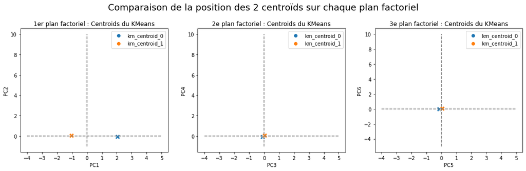

```python
# Représentation des centroids sur les plans factoriels

c_km=pd.DataFrame(centroid_projected_km, index=['km_centroid_'+str(i) for i in range(0,2)],
                  columns=['PC%s' % _ for _ in range(1,7)])


fig = plt.figure(figsize=(18, 10))
ax1 = fig.add_subplot(231)
sns.scatterplot(ax=ax1, x=c_km.iloc[:, 0], y=c_km.iloc[:, 1], hue=c_km.index, marker='X', s=100)
ax1.plot([-4, 5], [0, 0], color='grey', ls='--')
ax1.plot([0, 0], [-1, 10], color='grey', ls='--')
ax1.set_xticks(range(-4, 6))
ax1.legend()
ax1.set_title('1er plan factoriel : Centroids du KMeans')

ax3 = fig.add_subplot(232)
sns.scatterplot(ax=ax3, x=c_km.iloc[:, 2], y=c_km.iloc[:, 3], hue=c_km.index, marker='X', s=100)
ax3.plot([-4, 5], [0, 0], color='grey', ls='--')
ax3.plot([0, 0], [-1, 10], color='grey', ls='--')
ax3.set_xticks(range(-4, 6))
ax3.legend()
ax3.set_title('2e plan factoriel : Centroids du KMeans')

ax5 = fig.add_subplot(233)
sns.scatterplot(ax=ax5, x=c_km.iloc[:, 4], y=c_km.iloc[:, 5], hue=c_km.index, marker='X', s=100)
ax5.plot([-4, 5], [0, 0], color='grey', ls='--')
ax5.plot([0, 0], [-5, 10], color='grey', ls='--')
ax5.set_xticks(range(-4, 6))
ax5.legend()
ax5.set_title('3e plan factoriel : Centroids du KMeans')

fig.suptitle("Comparaison de la position des 2 centroïds sur chaque plan factoriel", fontsize=18, y=.95)
plt.show()
```

```python
# Comptage du nombre d'invidus par cluster
from collections import Counter
x = Counter(km.labels_)

#Analyse des clusters
print(f"Nombre d'individus dans chaque cluster : {sorted(x.items())}")
```

```
Nombre d'individus dans chaque cluster : [(0, 496), (1, 1004)]
```

Remarque :

Donc ici, 1004 billets ont été classés entre eux, et 496 entre eux.

```python
extracted_col = df_clustered['cluster_KMeans']
df_kmeans = new_data.join(extracted_col)
df_kmeans.head()
```

|  | is_genuine | diagonal | height_left | height_right | margin_low | margin_up | length | cluster_KMeans |
| --- | --- | --- | --- | --- | --- | --- | --- | --- |
| 0 | True | 171.81 | 104.86 | 104.95 | 4.52 | 2.89 | 112.83 | 0 |
| 1 | True | 171.46 | 103.36 | 103.66 | 3.77 | 2.99 | 113.09 | 1 |
| 2 | True | 172.69 | 104.48 | 103.50 | 4.40 | 2.94 | 113.16 | 1 |
| 3 | True | 171.36 | 103.91 | 103.94 | 3.62 | 3.01 | 113.51 | 1 |
| 4 | True | 171.73 | 104.28 | 103.46 | 4.04 | 3.48 | 112.54 | 1 |

```python
df_kmeans['cluster_KMeans'] = df_kmeans['cluster_KMeans'].astype('category')
df_kmeans.info()
```

```
<class 'pandas.core.frame.DataFrame'>
Int64Index: 1500 entries, 0 to 1438
Data columns (total 8 columns):
 #   Column          Non-Null Count  Dtype
---  ------          --------------  -----
 0   is_genuine      1500 non-null   category
 1   diagonal        1500 non-null   float64
 2   height_left     1500 non-null   float64
 3   height_right    1500 non-null   float64
 4   margin_low      1500 non-null   float64
 5   margin_up       1500 non-null   float64
 6   length          1500 non-null   float64
 7   cluster_KMeans  1500 non-null   category
dtypes: category(2), float64(6)
memory usage: 117.5 KB
```

```python
pd.crosstab(df_kmeans['is_genuine'], df_kmeans['cluster_KMeans'], dropna=False)
```

| cluster_KMeans is_genuine | 0 | 1 |
| --- | --- | --- |
| False | 459 | 41 |
| True | 37 | 963 |

```python
accuracy = (459+963)/1500
print(accuracy)
```

```
0.948
```

K-means a classé 459 billets faux comme faux et 963 billets vrais comme vrais. En revanche, il s'est trompé sur 41 faux qui ont été classés comme vrais et sur 37 vrais qui ont été classés comme faux. La régression logistique est un meilleur modèle.

## 4.3.2. On simule sur les billets_prod

```python
# Préparation des données
X_prod = billets_prod[billets_prod.columns[:6]].values
header = billets_prod.columns[:6]
features = billets_prod.columns
```

```python
# Centrage et Réduction
X_scaled_prod = preprocessing.StandardScaler().fit_transform(X_prod)
df_X_scaled_prod = pd.DataFrame(X_scaled_prod,columns=header)
df_X_scaled_prod.describe().round(4)
```

|  | diagonal | height_left | height_right | margin_low | margin_up | length |
| --- | --- | --- | --- | --- | --- | --- |
| count | 5.0000 | 5.0000 | 5.0000 | 5.0000 | 5.0000 | 5.0000 |
| mean | -0.0000 | -0.0000 | -0.0000 | -0.0000 | 0.0000 | -0.0000 |
| std | 1.1180 | 1.1180 | 1.1180 | 1.1180 | 1.1180 | 1.1180 |
| min | -1.0409 | -1.5744 | -1.2289 | -1.4857 | -1.6294 | -1.1240 |
| 25% | -0.6642 | -0.5022 | -1.1720 | -0.5905 | -0.6110 | -0.9371 |
| 50% | -0.2876 | -0.0508 | 0.4495 | 0.1443 | 0.4857 | -0.2891 |
| 75% | 0.1575 | 1.0214 | 0.9046 | 0.4382 | 0.5640 | 1.0941 |
| max | 1.8352 | 1.1060 | 1.0468 | 1.4937 | 1.1907 | 1.2561 |

```python
# Afficher les clusters KMeans sur les données brutes centrées et réduites
X_scaled_clustered_prod = pd.DataFrame(X_scaled_prod, columns=header)
X_scaled_clustered_prod['cluster_KMeans'] = km.predict(X_scaled_prod)
X_scaled_clustered_prod
```

|  | diagonal | height_left | height_right | margin_low | margin_up | length | cluster_KMeans |
| --- | --- | --- | --- | --- | --- | --- | --- |
| 0 | -0.664228 | -0.502224 | -1.228900 | 0.438224 | 0.485681 | -1.124014 | 0 |
| 1 | -0.287604 | -0.050787 | 0.449459 | 1.493702 | 0.564017 | -0.289103 | 0 |
| 2 | 0.157497 | 1.106022 | 0.904607 | 0.144293 | 1.190702 | -0.937094 | 0 |
| 3 | 1.835186 | 1.021377 | 1.046841 | -0.590533 | -1.629382 | 1.094107 | 1 |
| 4 | -1.040852 | -1.574388 | -1.172007 | -1.485686 | -0.611018 | 1.256104 | 1 |

Remarque :

On retrouve les mêmes résultats qu'avec les deux techniques précédentes.

# Test

```python
billets_test = pd.read_csv('billets_test.csv', sep=',')
billets_test = billets_test.drop(columns = "id", axis = 1)
billets_test.head()
```

|  | diagonal | height_left | height_right | margin_low | margin_up | length |
| --- | --- | --- | --- | --- | --- | --- |
| 0 | 172.09 | 103.95 | 103.73 | 4.39 | 3.09 | 113.19 |
| 1 | 171.52 | 104.17 | 104.03 | 5.27 | 3.16 | 111.82 |
| 2 | 171.78 | 103.80 | 103.75 | 3.81 | 3.24 | 113.39 |
| 3 | 172.02 | 104.08 | 103.99 | 5.57 | 3.30 | 111.10 |
| 4 | 171.79 | 104.34 | 104.37 | 5.00 | 3.07 | 111.87 |

```python
# Ajout d'une colonne "is_genuine_reg"
billets_test["is_genuine_log"] = np.nan
billets_test.head()
```

|  | diagonal | height_left | height_right | margin_low | margin_up | length | is_genuine_log |
| --- | --- | --- | --- | --- | --- | --- | --- |
| 0 | 172.09 | 103.95 | 103.73 | 4.39 | 3.09 | 113.19 | NaN |
| 1 | 171.52 | 104.17 | 104.03 | 5.27 | 3.16 | 111.82 | NaN |
| 2 | 171.78 | 103.80 | 103.75 | 3.81 | 3.24 | 113.39 | NaN |
| 3 | 172.02 | 104.08 | 103.99 | 5.57 | 3.30 | 111.10 | NaN |
| 4 | 171.79 | 104.34 | 104.37 | 5.00 | 3.07 | 111.87 | NaN |

```python
X_test = billets_test.drop(columns=['is_genuine_log', 'diagonal', 'height_left'])

# On applique le modèle pour faire les prédictions
billets_test['is_genuine_log'] = logreg.predict(X_test)
```

```python
billets_test.head(5)
```

|  | diagonal | height_left | height_right | margin_low | margin_up | length | is_genuine_log |
| --- | --- | --- | --- | --- | --- | --- | --- |
| 0 | 172.09 | 103.95 | 103.73 | 4.39 | 3.09 | 113.19 | True |
| 1 | 171.52 | 104.17 | 104.03 | 5.27 | 3.16 | 111.82 | False |
| 2 | 171.78 | 103.80 | 103.75 | 3.81 | 3.24 | 113.39 | True |
| 3 | 172.02 | 104.08 | 103.99 | 5.57 | 3.30 | 111.10 | False |
| 4 | 171.79 | 104.34 | 104.37 | 5.00 | 3.07 | 111.87 | False |